# Terms and Concepts

# Structural Equation Modeling

- Regression on steroids
- Model many relationships at once, rather than run single regressions
- Model variables that don’t technically exist!

# Structural Equation Modeling

- Model theorized causal relationships
  - Even if we did not measure them in a causal way, we can specify direction
- A mostly *confirmatory* procedure
  - Generally, you have a theory about the relationship before hand
  - Less descriptive/exploratory than traditional hypothesis testing
- Specific error control
  - You can be more specific about the error terms, rather than just one overall residual

# Concepts

- Latent variables
  - Represented by circles
  - Abstract phenomena you are trying to model
  - Are not represented by a number in the dataset
  - Linked to the measured variables
  - Represented indirectly by those variables

# Concepts

- Manifest or observed variables
  - Represented by squares
  - Measured from participants, business data, or other sources
  - While most measured variables are continuous, you can use categorical and ordered measures as well

# Concepts

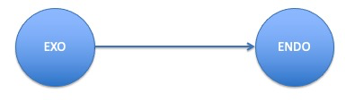

- Exogenous
  - These are synonymous with independent variables
  - They are thought to be the cause of something.
  - You can find these in a model where the arrow is leaving the variable
  - Exogenous (only) variables do not have an error term
  - Changes in these variables are represented by something else you aren’t modeling (like age, gender, etc.)

# Concepts

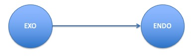

- Endogenous
  - These are synonymous with dependent variables
  - They are caused by the exogenous variables
  - In a model diagram, the arrow will be coming into the variable
  - Endogenous variables have error terms (assigned automatically by the software)

# Concepts

- Remember that `Y ~ X +` $\epsilon$
- Here that is `Endogenous ~ Exogenous + Residual`
- Sometimes people call residuals: *disturbances*

# Concepts

- Measurement model
  - The relationship between an exogenous latent variable and measured variables only.
  - Generally used when describing a confirmatory factor analysis

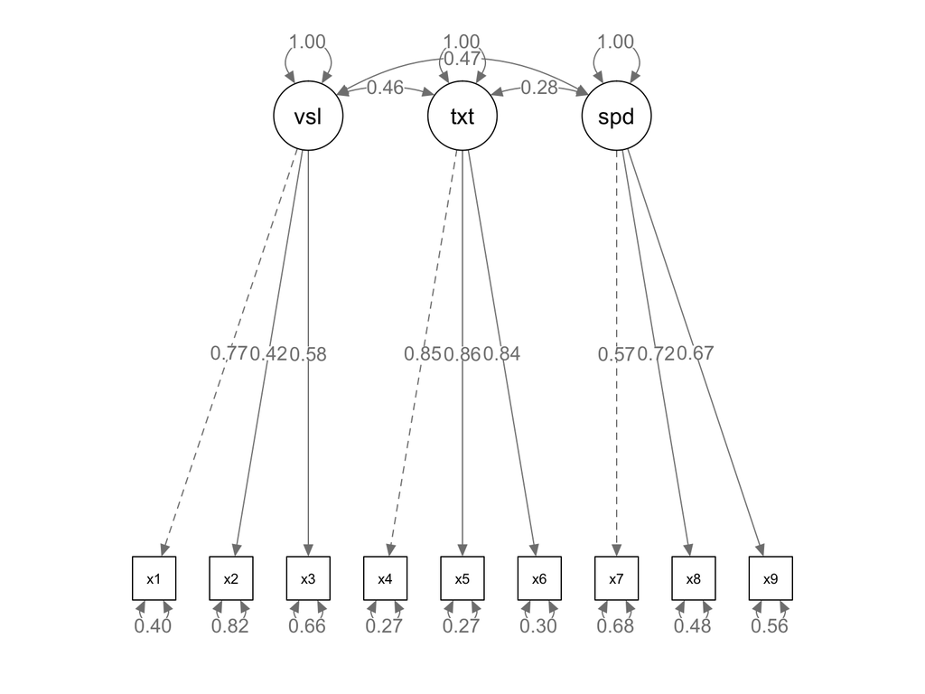

# Concepts

- Full SEM or fully latent SEM
  - A measurement model + causal relationships between latent variables

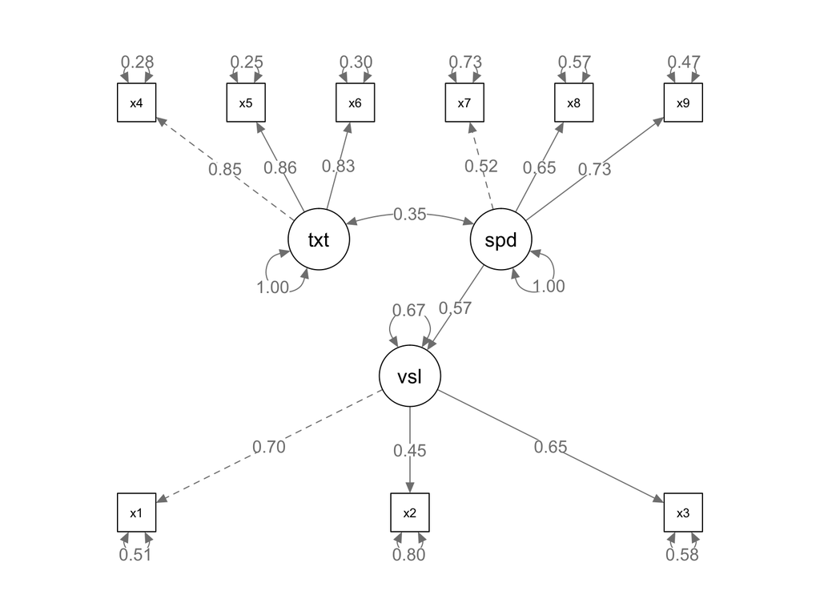

# Concepts

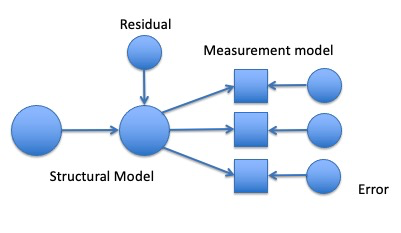

# Concepts

- Recursive models – arrows go only in one direction

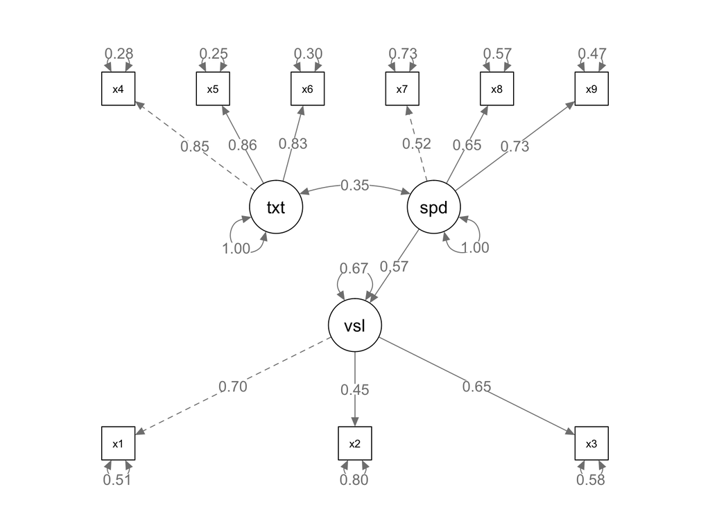

# Concepts

- Nonrecursive models – arrows go backwards to original variables

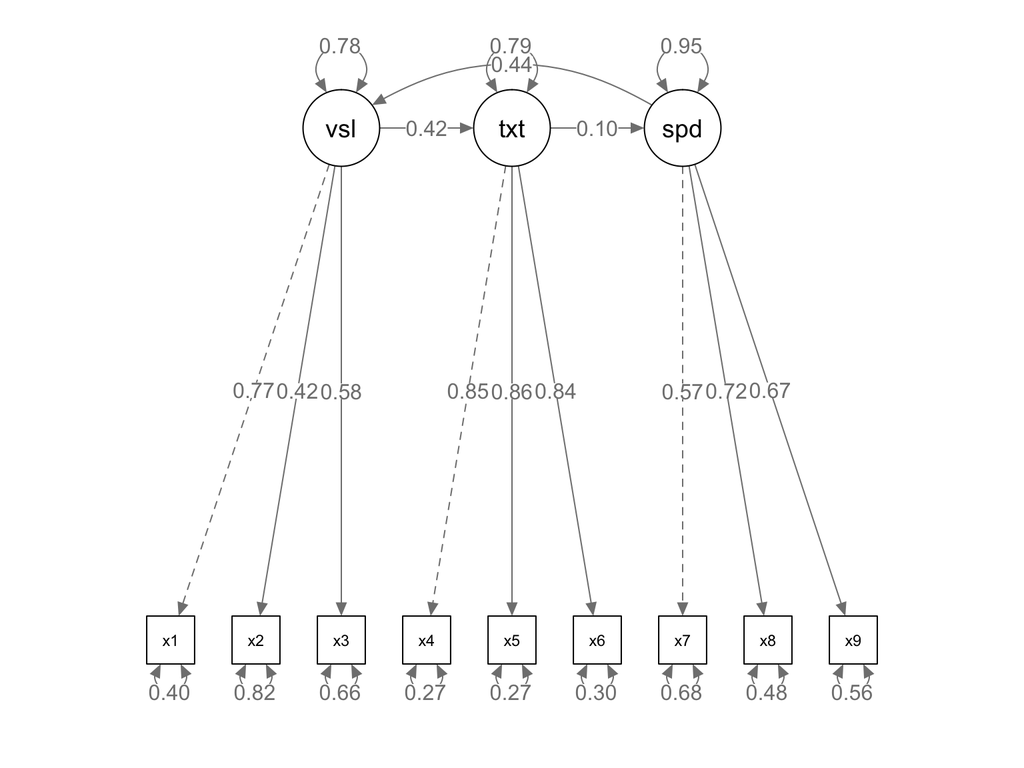

# Interpreting a SEM Diagram

- Recap:
- Circles are latent variables or error terms
  - They do not have numbers in the dataset
- Squares are measured or manifest variables
  - They will have a number in the dataset
- Single headed arrows indicate predicted direction of relationship (–>)
- Double headed arrows indicate variance or covariance (<–>)

# Parameters

Unstandardized estimates

- Single arrows are:
  - Between two variables that aren’t latent –> measured: `regressions ~`
  - Between measured and latents: `latent variables =~`
  - Indicate the coefficient *b* - the relationship between these two variables, like regression
- Double arrows are:
  - `Covariances ~~`: the amount two variables vary together
  - Remember that covariance is not scaled

# Parameters

```
#> lavaan 0.6-7 ended normally after 35 iterations
#>
#>   Estimator                                         ML
#>   Optimization method                           NLMINB
#>   Number of free parameters                         20
#>
#>   Number of observations                           301
#>
#> Model Test User Model:
#>
#>   Test statistic                               104.570
#>   Degrees of freedom                                25
#>   P-value (Chi-square)                           0.000
#>
#> Parameter Estimates:
#>
#>   Standard errors                             Standard
#>   Information                                 Expected
#>   Information saturated (h1) model          Structured
#>
#> Latent Variables:
#>                    Estimate  Std.Err  z-value  P(>|z|)
#>   visual =~
#>     x1                1.000
#>     x2                0.643    0.114    5.650    0.000
#>     x3                0.899    0.135    6.637    0.000
#>   textual =~
#>     x4                1.000
#>     x5                1.129    0.066   16.992    0.000
#>     x6                0.926    0.056   16.499    0.000
#>   speed =~
#>     x7                1.000
#>     x8                1.178    0.176    6.695    0.000
#>     x9                1.304    0.193    6.774    0.000
#>
#> Regressions:
#>                    Estimate  Std.Err  z-value  P(>|z|)
#>   visual ~
#>     speed             0.831    0.159    5.215    0.000
#>
#> Covariances:
#>                    Estimate  Std.Err  z-value  P(>|z|)
#>   textual ~~
#>     speed             0.196    0.048    4.118    0.000
#>
#> Variances:
#>                    Estimate  Std.Err  z-value  P(>|z|)
#>    .x1                0.694    0.107    6.470    0.000
#>    .x2                1.107    0.102   10.848    0.000
#>    .x3                0.738    0.096    7.696    0.000
#>    .x4                0.381    0.048    7.867    0.000
#>    .x5                0.423    0.058    7.227    0.000
#>    .x6                0.365    0.044    8.368    0.000
#>    .x7                0.869    0.083   10.494    0.000
#>    .x8                0.585    0.070    8.383    0.000
#>    .x9                0.480    0.072    6.685    0.000
#>    .visual            0.447    0.103    4.324    0.000
#>     textual           0.970    0.112    8.664    0.000
#>     speed             0.315    0.078    4.019    0.000
```

# Parameters

Standardized estimates: *note* there are several ways to “standardize” the solution, we will cover this more later

- Single arrows are:
  - `Regressions ~`: the $\beta$ coefficient, *z*-scored *b*
  - `Latent variables =~`: the correlation between a measured and latent variable, usually called loadings like EFA
- Double arrows are:
  - `Covariance ~~`: the correlation between two variables
- R-Squared: SMCs, Squared Multiple Correlation: variance accounted for in that endogenous variable

# Parameters

```
#> lavaan 0.6-7 ended normally after 35 iterations
#>
#>   Estimator                                         ML
#>   Optimization method                           NLMINB
#>   Number of free parameters                         20
#>
#>   Number of observations                           301
#>
#> Model Test User Model:
#>
#>   Test statistic                               104.570
#>   Degrees of freedom                                25
#>   P-value (Chi-square)                           0.000
#>
#> Parameter Estimates:
#>
#>   Standard errors                             Standard
#>   Information                                 Expected
#>   Information saturated (h1) model          Structured
#>
#> Latent Variables:
#>                    Estimate  Std.Err  z-value  P(>|z|)   Std.lv
#>   visual =~
#>     x1                1.000                               0.815
#>     x2                0.643    0.114    5.650    0.000    0.524
#>     x3                0.899    0.135    6.637    0.000    0.733
#>   textual =~
#>     x4                1.000                               0.985
#>     x5                1.129    0.066   16.992    0.000    1.112
#>     x6                0.926    0.056   16.499    0.000    0.912
#>   speed =~
#>     x7                1.000                               0.561
#>     x8                1.178    0.176    6.695    0.000    0.661
#>     x9                1.304    0.193    6.774    0.000    0.731
#>   Std.all
#>
#>     0.700
#>     0.446
#>     0.649
#>
```

[output cut: 49 more lines]

```
#>     1.000
#>     1.000
#>
#> R-Square:
#>                    Estimate
#>     x1                0.489
#>     x2                0.199
#>     x3                0.421
#>     x4                0.718
#>     x5                0.745
#>     x6                0.695
#>     x7                0.266
#>     x8                0.427
#>     x9                0.527
#>     visual            0.327
```

# Types of Research Questions

- Adequacy of the model
  - Model fit, $\chi^2$, and fit indices
  - No errors or Heywood cases
  - Low residuals, modification indices
- Testing Theory
  - Path significance: *note* large sample sizes, instead path *size*
  - Are there better competing models?
  - Modification indices

# Types of Research Questions

- Amount of variance (effect size): SMCS $R^2$
- Parameter Estimates: direction and strength
- Group differences:
  - Multi-group models, multiple indicators models (MIMIC)
- Longitudinal differences with Latent Growth Curves
- Multilevel modeling on repeated measures datasets

# Practical Issues

- Sample size: for parameter estimates to be accurate, you should have large samples
- How many? Hard to say, but often hundreds are necessary
- http://web.pdx.edu/~newsomj/semclass/ho_sample%20size.pdf
- https://www.ncbi.nlm.nih.gov/pmc/articles/PMC4334479/

# Practical Issues

- Sample Size: The N:q rule
  - Number of people, *N*
  - *q* number of estimated parameters
  - You want the N:q ratio to be 20:1 or greater in a perfect world, 10:1 if you can manage it.

# Hypothesis Testing

- Theory + Model Building
- Get the data
- Build the model
- Run the model
- Examine model fit with fit statistics
- Update, replicate

# Hypothesis Testing

- Examining model fit is based on residuals
  - Residuals are the error terms
  - `Y ~ X +` $\epsilon$
  - Want the residuals to be as small as possible
  - Those residuals are estimated from model (i.e., they are circles)
  - Smaller error implies that the model and data match - a more accurate representation of the relationships you are trying to model

# Approaches to Modeling

- Strictly confirmatory
  - You have a theorized model and you accept or reject it only.
- Alternative models
  - Comparison between many different models of the construct
  - These models are common in scale development, comparing the number of expected factors
- Model generating
  - The original model doesn’t work, so you improve it for further testing
  - Sometimes called E-SEM

# Approaches to Modeling

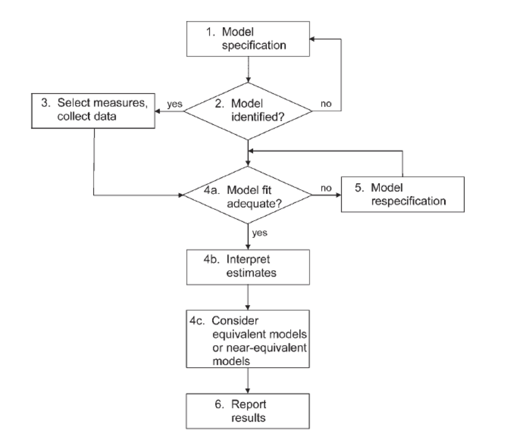

# Specification

- Specification is:
  - Generating the model hypothesis
  - Drawing out how you think the variables are related
  - Defining the model code
- Errors:
  - LOVE: left out variable error
  - Omitted predictors that are important but left out
  - Practically: you diagrammed something wrong, typed the code incorrectly, etc.

# Identification

- To be able to understand identification, you have to understand that SEM is an analysis of covariances
- You are trying to explain as much of the variance between variables with your model
- You can also estimate a mean structure
  - Often used in multigroup analysis

# Identification

- Models that are identified have a *unique* answer
  - `2x = 4` has *one* answer
  - `2x + y = 10` has *many* answers
- Models that are identified have one probable answer for all the parameters you are estimating

# Identification

- Identification is tied to:
  - Parameters to be estimated
  - Degrees of Freedom
- Most software programs help you out *but* always look for warnings

# Identification

- Free parameter – will be estimated from the data
- Fixed parameter – will be set to a specific value
  - Sometimes set to 1 as an *indicator* or *marker* variable
  - Sometimes practically set when model issues arise
- Constrained parameter – estimated from the data with some specific rule
  - Setting a value equal to another parameter
  - Also known as an equality constraint
  - Cross group equality constraints – mostly used in multigroup models, forces the same paths to be equal (but estimated) for each group

# Identifying What’s What

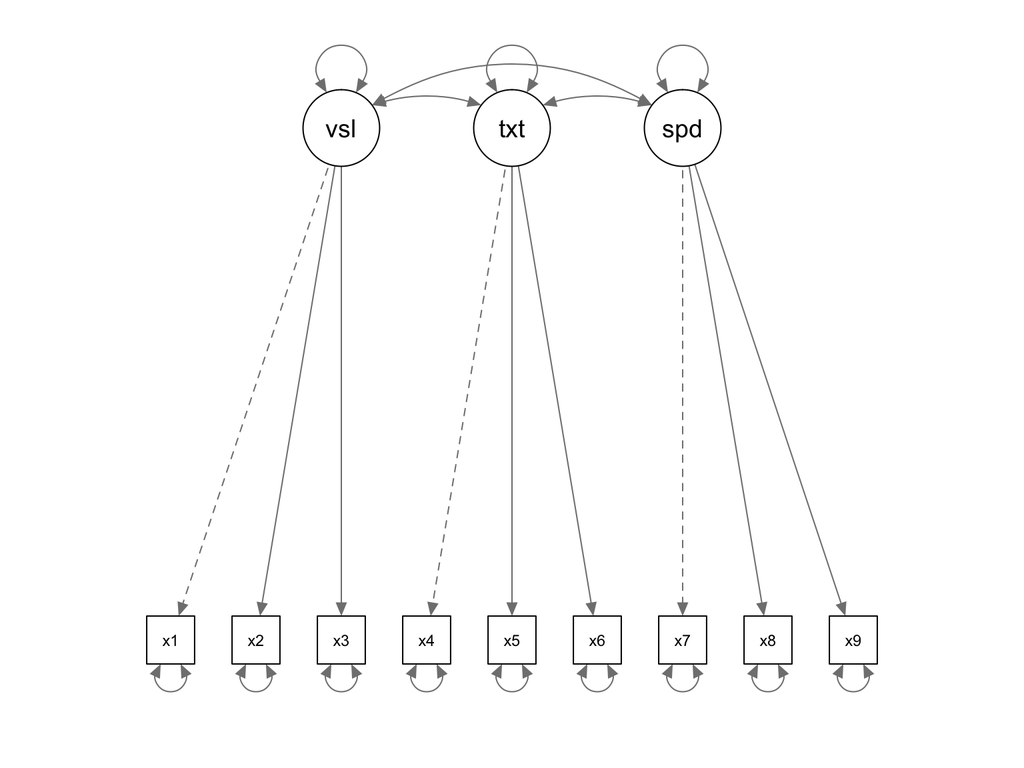

- 3 variances on latent variables
- 3 covariances between latent variables
- 6 latent variable loadings
- 9 error variances

# Identifying What’s What

- Degrees of Freedom
  - DF is *not* related to sample size
- Calculate possible parameters: $\frac{p \times (p+1)}{2}$
  - P is the number of measured variables
  - $\frac{9 \times (9+1)}{2}$ = 45
- Subtract the number of estimated parameters
  - 45 - 21 = 24

# Identifying What’s What

- Did we get it right?

```
#> lavaan 0.6-7 ended normally after 35 iterations
#>
#>   Estimator                                         ML
#>   Optimization method                           NLMINB
#>   Number of free parameters                         21
#>
#>   Number of observations                           301
#>
#> Model Test User Model:
#>
#>   Test statistic                                85.306
#>   Degrees of freedom                                24
#>   P-value (Chi-square)                           0.000
#>
#> Parameter Estimates:
#>
#>   Standard errors                             Standard
#>   Information                                 Expected
#>   Information saturated (h1) model          Structured
#>
#> Latent Variables:
#>                    Estimate  Std.Err  z-value  P(>|z|)
#>   visual =~
#>     x1                1.000
#>     x2                0.554    0.100    5.554    0.000
#>     x3                0.729    0.109    6.685    0.000
#>   textual =~
#>     x4                1.000
#>     x5                1.113    0.065   17.014    0.000
#>     x6                0.926    0.055   16.703    0.000
#>   speed =~
#>     x7                1.000
#>     x8                1.180    0.165    7.152    0.000
#>     x9                1.082    0.151    7.155    0.000
#>
#> Covariances:
#>                    Estimate  Std.Err  z-value  P(>|z|)
#>   visual ~~
#>     textual           0.408    0.074    5.552    0.000
#>     speed             0.262    0.056    4.660    0.000
#>   textual ~~
#>     speed             0.173    0.049    3.518    0.000
#>
#> Variances:
#>                    Estimate  Std.Err  z-value  P(>|z|)
#>    .x1                0.549    0.114    4.833    0.000
#>    .x2                1.134    0.102   11.146    0.000
#>    .x3                0.844    0.091    9.317    0.000
#>    .x4                0.371    0.048    7.779    0.000
#>    .x5                0.446    0.058    7.642    0.000
#>    .x6                0.356    0.043    8.277    0.000
#>    .x7                0.799    0.081    9.823    0.000
#>    .x8                0.488    0.074    6.573    0.000
#>    .x9                0.566    0.071    8.003    0.000
#>     visual            0.809    0.145    5.564    0.000
#>     textual           0.979    0.112    8.737    0.000
#>     speed             0.384    0.086    4.451    0.000
```

# Identification

- Just identified models mean the *df* = 0
  - Generally, not a good sign
  - Cross panel lagged models are set up this way on purpose
- Over identified models mean *df* > 0
  - You want this!
- Under identified models mean the *df* < 0
  - You can’t run this!

# Identification

- Empirical under identification
  - When two observed variables are highly correlated, which effectively reduces the number of parameters you can estimate
- Even if you have an over identified model, you can have under identified sections

# Identification

- How do I create identified models?
  - Scaling/reference/marker variables: a parameter you set to 1
  - Helps increase *df* by eliminating a free parameter
  - Gives the model a scale
  - Can be done in a couple of ways, generally on the measurement model
  - Pay attention to the number of variables attached to a latent variable in a measurement model

# Identification

- Does the marker variable matter?
  - No, it should not change the model if you change which variable you set it to
  - If it does, something is likely weird with your model
  - The reference variable will not have an estimated unstandardized parameter
  - You will get a standardized parameter, so you can check if the variable is loading like what you think it should
  - If you need a *p*-value for that parameter, you can run the model twice

# Identification

```
#> lavaan 0.6-7 ended normally after 35 iterations
#>
#>   Estimator                                         ML
#>   Optimization method                           NLMINB
#>   Number of free parameters                         21
#>
#>   Number of observations                           301
#>
#> Model Test User Model:
#>
#>   Test statistic                                85.306
#>   Degrees of freedom                                24
#>   P-value (Chi-square)                           0.000
#>
#> Parameter Estimates:
#>
#>   Standard errors                             Standard
#>   Information                                 Expected
#>   Information saturated (h1) model          Structured
#>
#> Latent Variables:
#>                    Estimate  Std.Err  z-value  P(>|z|)   Std.lv
#>   visual =~
#>     x1                1.000                               0.900
#>     x2                0.554    0.100    5.554    0.000    0.498
#>     x3                0.729    0.109    6.685    0.000    0.656
#>   textual =~
#>     x4                1.000                               0.990
#>     x5                1.113    0.065   17.014    0.000    1.102
#>     x6                0.926    0.055   16.703    0.000    0.917
#>   speed =~
#>     x7                1.000                               0.619
#>     x8                1.180    0.165    7.152    0.000    0.731
#>     x9                1.082    0.151    7.155    0.000    0.670
#>   Std.all
#>
#>     0.772
#>     0.424
#>     0.581
#>
```

[output cut: 34 more lines]

```
#>     textual           0.979    0.112    8.737    0.000    1.000
#>     speed             0.384    0.086    4.451    0.000    1.000
#>   Std.all
#>     0.404
#>     0.821
#>     0.662
#>     0.275
#>     0.269
#>     0.298
#>     0.676
#>     0.477
#>     0.558
#>     1.000
#>     1.000
#>     1.000
```

# Identification

- If you have a complex model:
  - Start small – work with the measurement model components first, since they have simple identification rules
  - Then work up to adding variables to see where the problem occurs
  - `lavaan` gives you somewhat good warnings
  - Page 130 Kline has a great set of references for identification

# Positive Definite Matrices

- Dreaded: `hessian matrix not definite`
- What that indicates is the following:
  - Matrix is singular
  - Eigenvalues are negative
  - Determinants are zero or negative
  - Correlations are out of bounds

# Positive Definite Matrices

- Simply put: each column has to indicate something unique
  - Therefore, if you have two columns that are perfectly correlated OR are linear transformations of each other, you will have a singular matrix
- Negative eigenvalues – remember that eigenvalues are combinations of variance
  - And variance is positive (it’s squared in the formula!)
- Determinants are the products of eigenvalues
  - Again, they cannot be negative
  - A zero determinant indicates a singular matrix
- Out of bounds – basically that means that the data has correlations over 1 or negative variances (Heywood case)

# Summary

In this lecture you’ve learned:

- Basic terminology
- Beginning to map pictures to code definition (~) to output
- Beginning steps to specifying and creating identified models
- Degrees of freedom
- Errors you may encounter